# Assignment 3 - Diamond Price Estimation

Umut Mete Saka

## Introduction

This Assignment aims to imply explanatory data analysis on diamonds data from ggplot2 package and build a multiple linear regression model on the data to predict the price indicator using the other inputs. This is going to be a supervised learning model.

## Starting Points

First of all I am going to load required packages. My data is in the ggplot2 package which is in tidyverse. Therefore I do not need to import my data exclusively.

```r
library(tidyverse)
library(lubridate)
library(tidyr)
library(knitr)
library(gridExtra)
library(tree)
```

Now I can glimpse my data to understand its characteristics.

```r
glimpse(diamonds)
```

```
## Rows: 53,940
## Columns: 10
## $ carat   <dbl> 0.23, 0.21, 0.23, 0.29, 0.31, 0.24, 0.24, 0.26, 0.22, 0.23, 0…
## $ cut     <ord> Ideal, Premium, Good, Premium, Good, Very Good, Very Good, Ve…
## $ color   <ord> E, E, E, I, J, J, I, H, E, H, J, J, F, J, E, E, I, J, J, J, I…
## $ clarity <ord> SI2, SI1, VS1, VS2, SI2, VVS2, VVS1, SI1, VS2, VS1, SI1, VS1,…
## $ depth   <dbl> 61.5, 59.8, 56.9, 62.4, 63.3, 62.8, 62.3, 61.9, 65.1, 59.4, 6…
## $ table   <dbl> 55, 61, 65, 58, 58, 57, 57, 55, 61, 61, 55, 56, 61, 54, 62, 5…
## $ price   <int> 326, 326, 327, 334, 335, 336, 336, 337, 337, 338, 339, 340, 3…
## $ x       <dbl> 3.95, 3.89, 4.05, 4.20, 4.34, 3.94, 3.95, 4.07, 3.87, 4.00, 4…
## $ y       <dbl> 3.98, 3.84, 4.07, 4.23, 4.35, 3.96, 3.98, 4.11, 3.78, 4.05, 4…
## $ z       <dbl> 2.43, 2.31, 2.31, 2.63, 2.75, 2.48, 2.47, 2.53, 2.49, 2.39, 2…
```

There are 10 attributes in the data. These attributes are:

- Carat : Weight of the diamond
- Cut : Quality of the cut
- Color : Diamond colour, from D (best) to J (worst)
- Clarity : A measurement of how clear the diamond is (I1 (worst), SI2, SI1, VS2, VS1, VVS2, VVS1, IF (best))
- Depth : Total depth percentage = z / mean(x, y)
- Table : Width of top of diamond relative to widest point
- Price : Price in US dollars *Which is going to be my output in the predictive model*
- x : Length in mm
- y : Width in mm
- z : Depth in mm

I observe that there are 6 numerical input attributes. So I am going to see the correlation between these attributes and price.

```r
Diamonds_num <-  diamonds %>%
  select(carat,depth,table,price,x,y,z)

kable(cor(Diamonds_num$price, Diamonds_num), caption = "Correlation between price")
```

Correlation between price

| carat | depth | table | price | x | y | z |
| --- | --- | --- | --- | --- | --- | --- |
| 0.9215913 | -0.0106474 | 0.1271339 | 1 | 0.8844352 | 0.8654209 | 0.8612494 |

From the correlation table I can see that, carat, x, y and z have high positive correlation with price. However table and depth seems uncorrelated. So I am going to plot the correlated attributes with price.

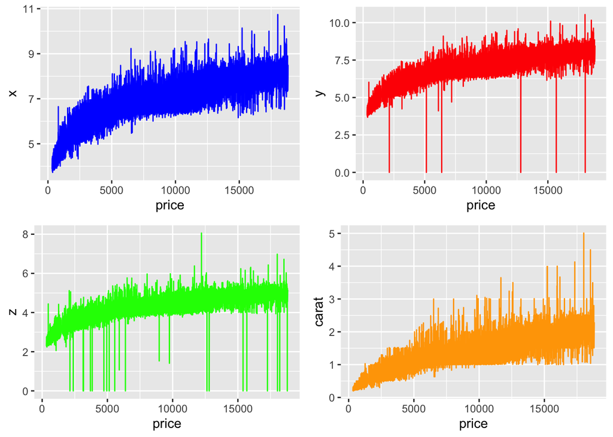

```r
plot1 <- Diamonds_num %>% select(-table, -depth) %>% filter(x>3)%>% ggplot(aes(price,x)) + geom_line(color = "blue")
plot2 <- Diamonds_num %>% select(-table, -depth) %>% filter(y<20) %>% ggplot(aes(price,y)) + geom_line(color = "red")
plot3 <- Diamonds_num %>% select(-table, -depth) %>% filter(z<10) %>% ggplot(aes(price,z)) + geom_line(color = "green")
plot4 <- Diamonds_num %>% select(-table, -depth) %>% ggplot(aes(price,carat)) + geom_line(color = "orange")

grid.arrange(plot1,plot2,plot3,plot4,nrow = 2)
```

Now I want to see the effect of the categorical variables on price. There are 3 categorical variables which are cut, color and clarity.

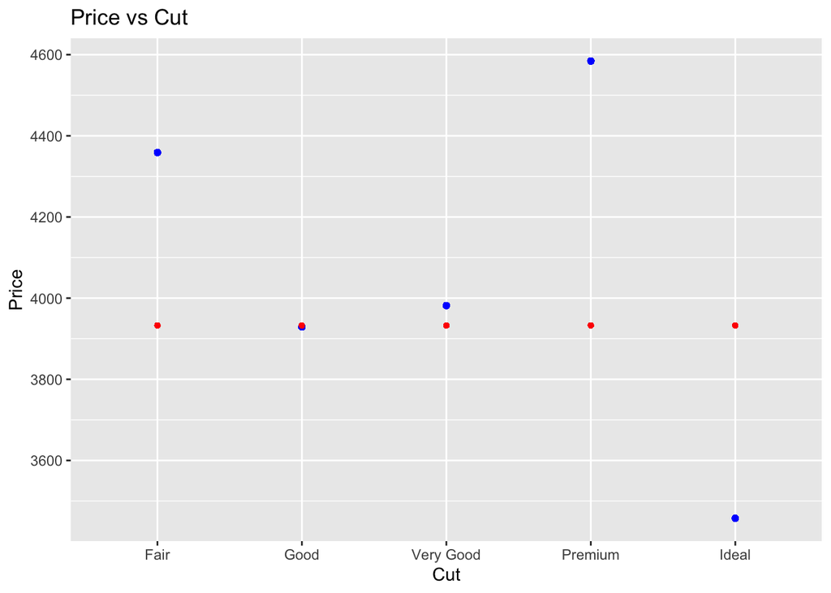

```r
Diamonds_cat <-  diamonds %>% select(price,cut,color,clarity)

Diamonds_cat %>% select(price,cut)  %>% group_by(cut) %>% mutate(mean_price = mean(price)) %>% ggplot(aes(x = cut)) + geom_point(aes(y = mean_price),color = "blue",cex= 1.3) + geom_point(aes(y=mean(price)),color = "red",cex = 1) +xlab("Cut")+ylab("Price")+ggtitle("Price vs Cut")
```

It seems that some cut types has significant effect on the price. Premium and Fair cuts are much more expensive than average price and Ideal cut is much lower.

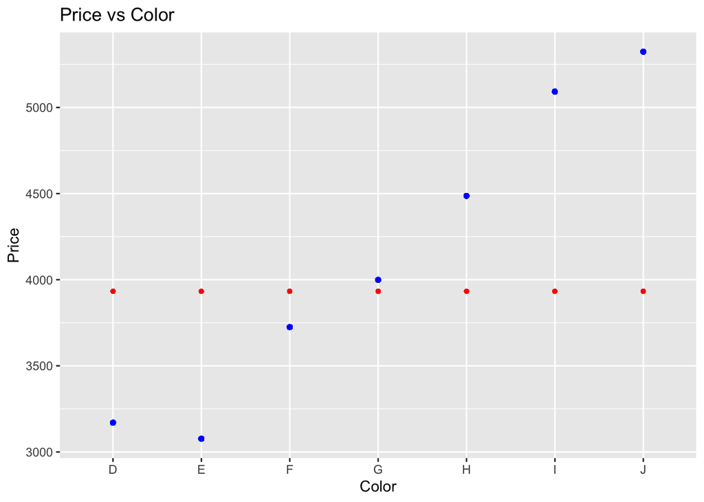

```r
Diamonds_cat %>% select(price,color) %>% group_by(color) %>% mutate(mean_price = mean(price)) %>% ggplot(aes(x = color)) + geom_point(aes(y = mean_price),color = "blue",cex= 1.3) + geom_point(aes(y=mean(price)),color = "red",cex = 1) +xlab("Color")+ylab("Price")+ggtitle("Price vs Color")
```

Also Color seems to have significant effect on Price.

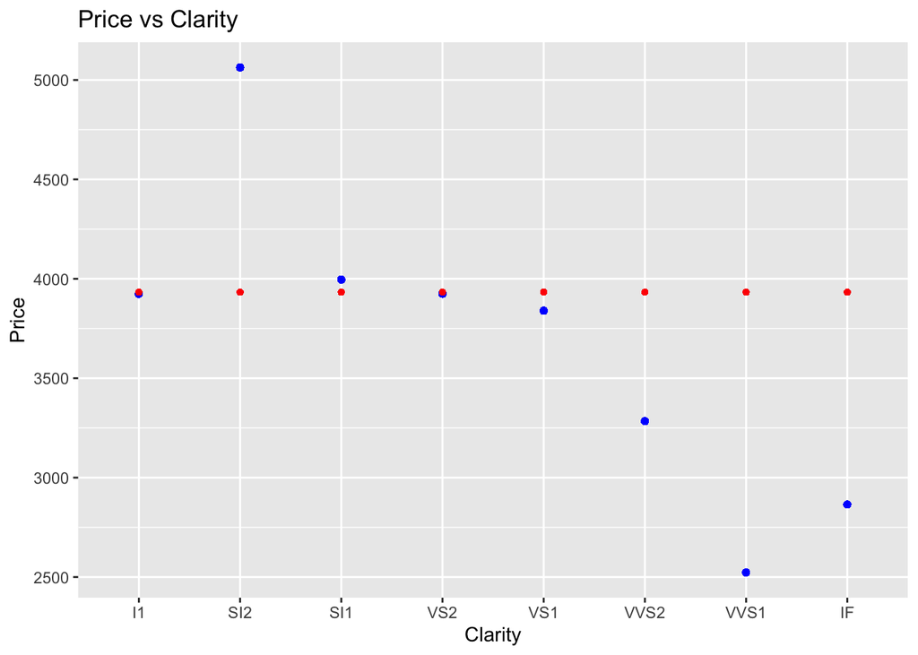

```r
Diamonds_cat %>% select(price,clarity) %>% group_by(clarity) %>% mutate(mean_price = mean(price)) %>% ggplot(aes(x = clarity)) + geom_point(aes(y = mean_price),color = "blue",cex= 1.3) + geom_point(aes(y=mean(price)),color = "red",cex = 1) +xlab("Clarity")+ylab("Price")+ggtitle("Price vs Clarity")
```

Also some types of clarity has effect on price.

## Predictive Models

First I will start with dividing data into test and train datasets. Train data set will use random 70% of the data.

```r
set.seed(48)
a <- sample(1:nrow(diamonds),nrow(diamonds)*0.7)
diamonds_train <- diamonds[a,]
diamonds_test <- diamonds[-a,]
```

#### Multiple Linear Regression

I am going to build a multiple linear regression model to predict the price. In my first model I am going to use every input attribute and see their significance levels.

```r
model1 <- lm(price~.,diamonds_train)

summary(model1)
```

```
##
## Call:
## lm(formula = price ~ ., data = diamonds_train)
##
## Residuals:
##      Min       1Q   Median       3Q      Max
## -14942.1   -584.6   -182.5    374.9  10698.7
##
## Coefficients:
##              Estimate Std. Error t value Pr(>|t|)
## (Intercept)  6341.544    459.401  13.804  < 2e-16 ***
## carat       11449.056     57.178 200.237  < 2e-16 ***
## cut.L         567.189     26.417  21.471  < 2e-16 ***
## cut.Q        -284.168     21.098 -13.469  < 2e-16 ***
## cut.C         130.198     18.309   7.111 1.17e-12 ***
## cut^4          -6.709     14.598  -0.460  0.64584
## color.L     -1962.658     20.515 -95.669  < 2e-16 ***
## color.Q      -673.933     18.678 -36.081  < 2e-16 ***
## color.C      -169.825     17.387  -9.767  < 2e-16 ***
## color^4        48.236     15.901   3.033  0.00242 **
## color^5       -89.616     15.023  -5.965 2.47e-09 ***
## color^6       -35.321     13.681  -2.582  0.00983 **
## clarity.L    4051.192     36.281 111.662  < 2e-16 ***
## clarity.Q   -1888.771     33.900 -55.716  < 2e-16 ***
## clarity.C     947.523     28.927  32.755  < 2e-16 ***
## clarity^4    -338.225     22.988 -14.713  < 2e-16 ***
## clarity^5     224.721     18.649  12.050  < 2e-16 ***
## clarity^6      29.676     16.155   1.837  0.06622 .
## clarity^7      91.474     14.283   6.404 1.53e-10 ***
## depth         -68.335      5.217 -13.099  < 2e-16 ***
## table         -26.743      3.406  -7.852 4.19e-15 ***
## x           -1169.985     48.692 -24.028  < 2e-16 ***
## y              97.182     39.303   2.473  0.01342 *
## z             -53.552     34.726  -1.542  0.12305
## ---
## Signif. codes:  0 '***' 0.001 '**' 0.01 '*' 0.05 '.' 0.1 ' ' 1
##
## Residual standard error: 1114 on 37734 degrees of freedom
## Multiple R-squared:  0.922,  Adjusted R-squared:  0.922
## F-statistic: 1.94e+04 on 23 and 37734 DF,  p-value: < 2.2e-16
```

My r^2 value is 0.92 which shows a nice fit to the data.

Now I will run the model on test data and calculate Mean Absolute Percentage Error.

```r
diamonds_test <-  diamonds_test %>% mutate(predicted_values_lm = predict(model1,diamonds_test))

MAPE_model_lm <- mean(abs((diamonds_test$price - diamonds_test$predicted_values_lm) / diamonds_test$price)) * 100
```

My Multiple Linear Regression model worked with 39.19% Error.

#### Tree Model

My second model is a decision tree.

```r
model2 <- tree(price~.,diamonds_train)
summary(model2)
```

```
##
## Regression tree:
## tree(formula = price ~ ., data = diamonds_train)
## Variables actually used in tree construction:
## [1] "carat"   "y"       "clarity"
## Number of terminal nodes:  6
## Residual mean deviance:  1908000 = 7.203e+10 / 37750
## Distribution of residuals:
##    Min. 1st Qu.  Median    Mean 3rd Qu.    Max.
## -9757.0  -530.2  -158.2     0.0   545.3 13170.0
```

It is a tree with 6 nodes. Lets visualize it:

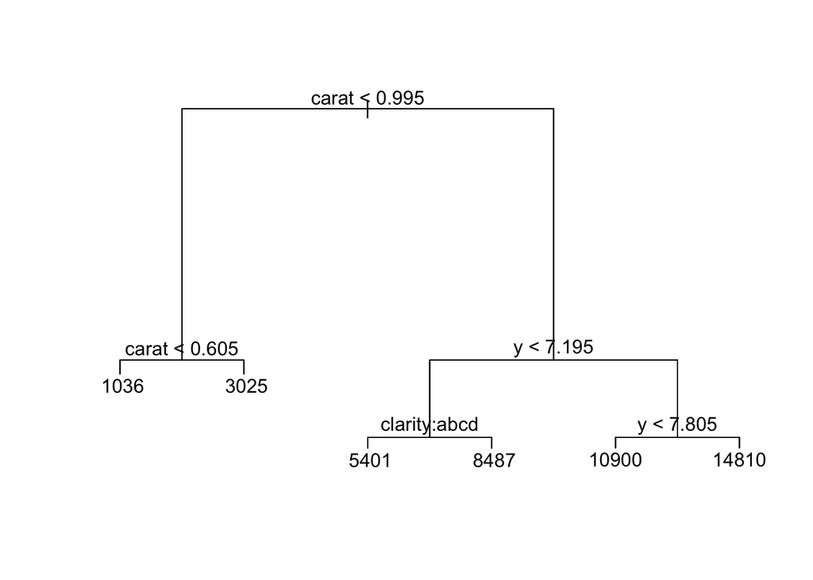

```r
plot(model2)
text(model2)
```

```r
diamonds_test <-  diamonds_test %>% mutate(predicted_values_tree = predict(model2,diamonds_test))

MAPE_model_tree <- mean(abs((diamonds_test$price - diamonds_test$predicted_values_tree) / diamonds_test$price)) * 100
```

My tree model worked with 32.46% Error.

Finally I want to visualize the model outcomes with the real data.

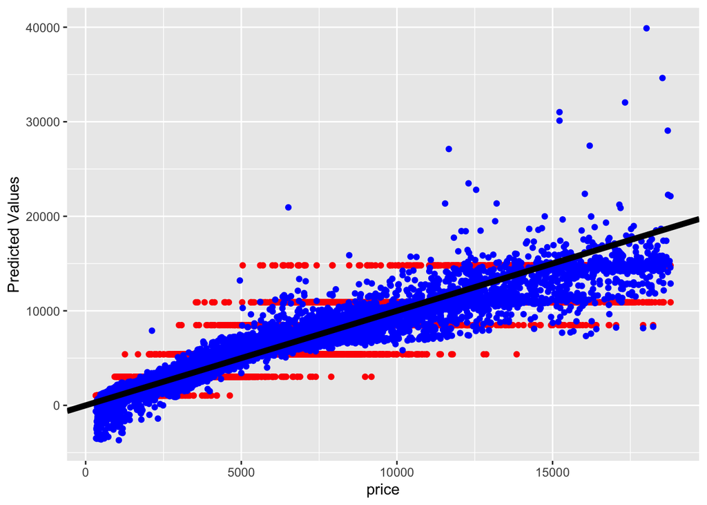

```r
b <- seq(1:nrow(diamonds_test))
diamonds_test %>% mutate(index=b) %>% ggplot(aes(x=price)) + geom_point(aes(y=predicted_values_tree),color = "red") + geom_point(aes(y=predicted_values_lm),color = "blue") + geom_abline(aes(intercept=0,slope=1),cex =2) + ylab("Predicted Values")
```

When we look at the predicted value points (blue is from lm model and red is from tree model) There is a obvious fit with the x=y line which shows us our predictions fit well to the real price data.